# Neotoma Resources on Choctaw Reservation and with Choctaw Cultural Affiliation

April 2024

## Introduction

This page will briefly survey paleoecological records from sites with Choctaw cultural affiliation held by the Neotoma Paleoecology Database. This page was created by Nick Hoffman, as a project for the [Ethical Open Science Research Coordination Network](https://eos-rcn.github.io/web/) (EOS RCN).The leader of the EOS RCN is Jessica Blois, Professor at UC-Merced. If you would like to explore these records or other Neotoma data further, we are happy to help with that, so please reach out to either of us at nicholashoffman@ucmerced.edu or jblois@ucmerced.edu.

### About [Neotoma](https://neotomadb.org)

[Neotoma](https://neotomadb.org) was formed in 2006 as a federated database constituted by a set of more specialized paleoecological databases. This means that Neotoma brings together paleoecological data from a range of proxy types (e.g., pollen, charcoal, testate amoebae), regions (e.g., North America, Latin America, Europe), and time periods (e.g., Pliocene, Pleistocene, Holocene). Neotoma incorporates data collected over more than 150 years.

## Neotoma and Native Lands

Neotoma contains records from upwards of 22,000 sites. Many of these sites are affiliated with native lands. A subset of these sites comes from federally recognized reservations in the United States.

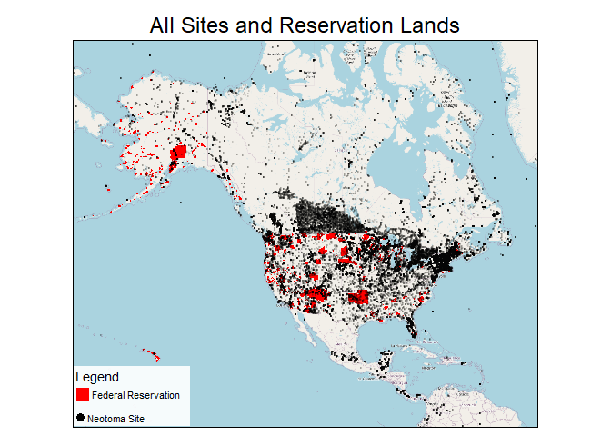

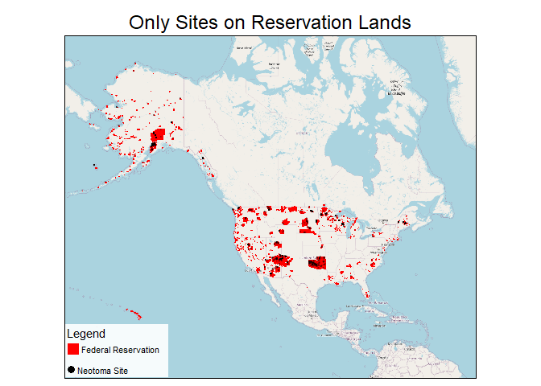

The following table counts the number of sites (n) from Neotoma that fall within the borders of federally recognized reservations. Overall, there are 692 sites on 105 reservations. The Choctaw reservation has several Neotoma sites.

| NAME | n |
| --- | --- |
| Navajo Nation | 177 |
| Menominee | 61 |
| Chickasaw | 30 |
| Cheyenne-Arapaho | 28 |
| Hopi | 21 |
| White Earth | 19 |
| Kenaitze | 18 |
| Blackfeet | 15 |
| Cherokee | 15 |
| Kiowa-Comanche-Apache-Fort Sill Apache | 13 |

[output cut: 95 more lines]

## Neotoma Resources on the Choctaw Reservation

The following map shows the location of Neotoma sites on the Choctaw Reservation. There are (as of April 2024) 9 distinct sites, but some of them may be close together, so 9 dots are not necessarily distinguishable on the map.

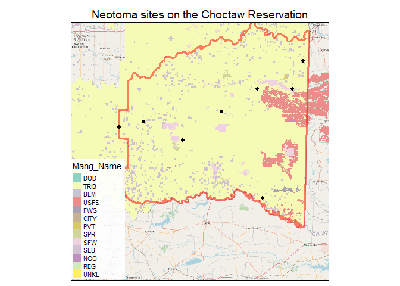

And the following table lists some information about those sites.

| siteid | sitename | sitedescription |
| --- | --- | --- |
| 804 | Ferndale Bog | Peat bog on Jackfork sandstone ridge. Physiography: Ouachita Mountains. Surrounding vegetation: elm/oak/hickory/pine/willow. |
| 1732 | Natural Lake | Lake on floodplain, formed on shale. Physiography: Ouachita Mountains. Surrounding vegetation: cattails, willows, elms, oaks. |
| 3831 | Spiro Site [34Lf-46] |  |
| 3841 | Wann [34LF27] |  |
| 3842 | Scott [34LF11] |  |
| 6098 | McCutchan-McLaughlin [34LT11] |  |
| 22813 | Coalgate Reservoir |  |
| 23197 | Upper Clear Boggy Creek Site 9 Reservoir |  |
| 23220 | Whitegrass-Waterhole Creeks Site 9 Reservoir |  |

We can further inspect the sites by the kinds of data they contain. Neotoma sites from the Choctaw Reservation concern pollen, vertebrate fauna, diatom, water chemistry and loss-on-ignition.

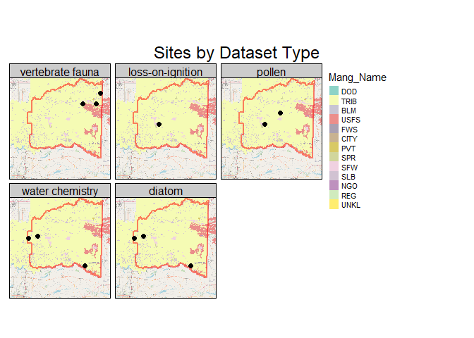

| data.datasettype | n |
| --- | --- |
| pollen | 4 |
| vertebrate fauna | 4 |
| diatom | 3 |
| water chemistry | 3 |
| loss-on-ignition | 1 |

Physical specimens are not typically preserved for all types of datasets, and Neotoma doesn’t have perfect information about the disposition of the physical specimens even when they do exist. What we do know is that for Neotoma data collected from the Choctaw Reservation, the University of Missouri and University of Oklahoma hold physical specimens.

| repository | types | n |
| --- | --- | --- |
| University of Missouri | vertebrate fauna | 1 |
| University of Oklahoma | vertebrate fauna | 1 |

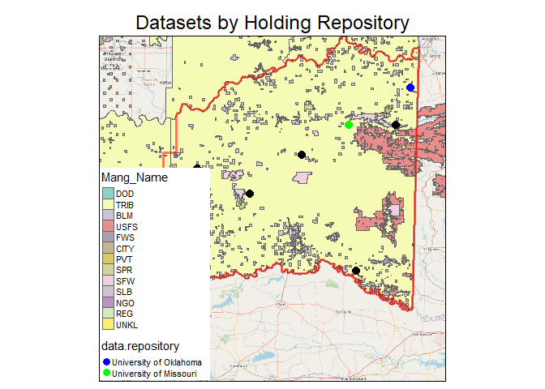

## Other Neotoma resources with Choctaw Cultural Affiliation

In addition to the Neotoma resources on the Choctaw Reservation, we’ve used the [Native Land API](https://native-land.ca/resources/api-docs) to filter for Neotoma sites on other lands with Choctaw cultural affiliation. As of April 2024, there were no Neotoma resources on the Isle de Jean Charles but the other location with Choctaw cultural affiliation does have Neotoma resources on it.

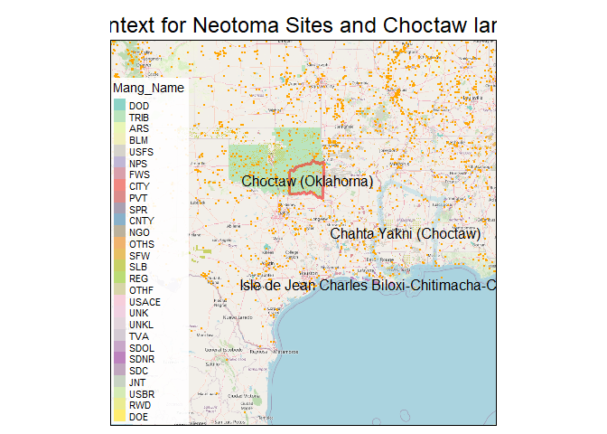

On these other lands with Choctaw cultural affiliation (named Chahta Yakni (Choctaw) and Isle de Jean Charles Biloxi-Chitimacha-Choctaw on the native-land.ca website), there are 51 distinct sites with data on a range of proxy types. The repositories associated with the physical specimens for these datasets are more various compared to those on the Choctaw Reservation.

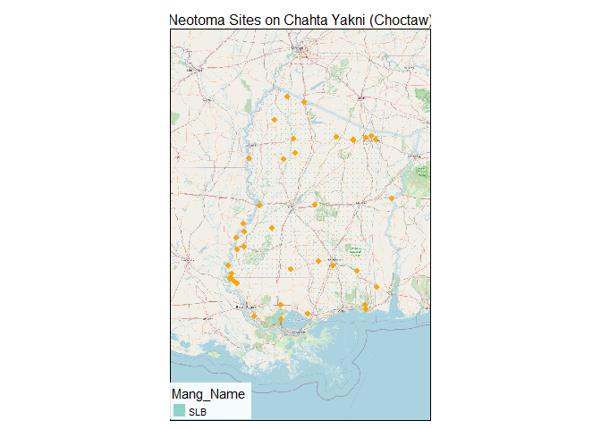

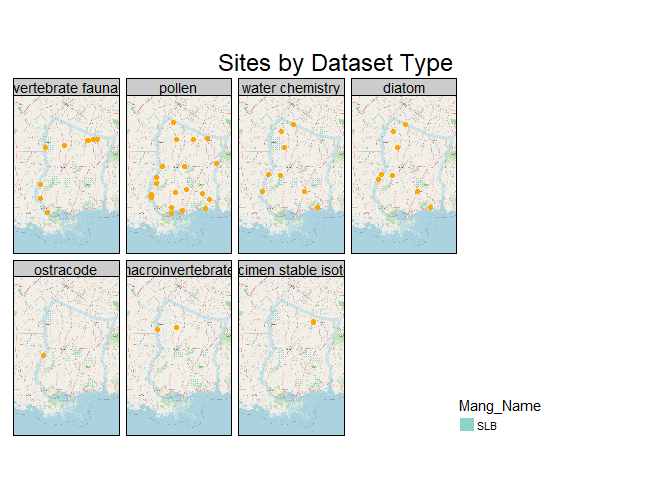

| data.datasettype | n |
| --- | --- |
| pollen | 24 |
| diatom | 15 |
| vertebrate fauna | 12 |
| water chemistry | 9 |
| macroinvertebrate | 2 |
| specimen stable isotope | 2 |
| ostracode | 1 |

| repository | data.datasettype | n |
| --- | --- | --- |
| Academy of Natural Sciences, Philadelphia | diatom | 6 |
| Museum of Mississippi History | vertebrate fauna | 4 |
| Louisiana State University | vertebrate fauna | 2 |
| Florida State University | vertebrate fauna | 1 |
| National Museum of Natural History | vertebrate fauna | 1 |
| University of Mississippi Museum | vertebrate fauna | 1 |

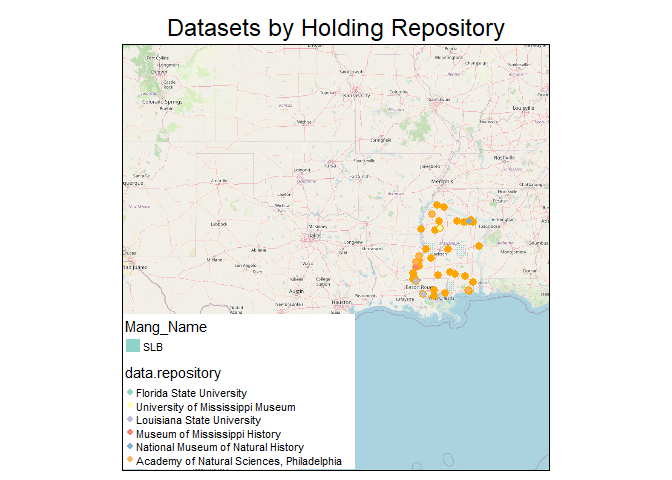